# Plastic Pollution

Fatou Seye

03/11/2021

[figure not shown]

Cette base de données porte sur la pollution en plastique et elle vient de l’association Break Free From Plastic. Cette dernière lutte contre la pollution, notamment les déchets plastiques qui sont rejetés par les grandes entreprises de fabrication. Ce sujet est très intéressant, il est d’ailleurs toujours d’actualité, on va ainsi faire des manipulations avec cette de données pour en aprrendre plus sur la pollution en plastique pendant les années 2019 et 2020.

```r
library(tidytuesdayR)
library(tidyverse)
```

### Importation des données :

```r
tuesdata <- tidytuesdayR::tt_load('2021-01-26')
```

[output not shown]

```
## --- Compiling #TidyTuesday Information for 2021-01-26 ----
```

[output not shown]

```
## --- There is 1 file available ---
```

[output not shown]

```
## --- Starting Download ---
```

[output not shown]

[output not shown]

```
## --- Download complete ---
```

```r
tuesdata <- tidytuesdayR::tt_load(2021, week = 5)
```

[output not shown]

[output not shown]

```
## --- Compiling #TidyTuesday Information for 2021-01-26 ----
```

[output not shown]

```
## --- There is 1 file available ---
```

[output not shown]

```
## --- Starting Download ---
```

[output not shown]

[output not shown]

```
## --- Download complete ---
```

```r
plastics <- tuesdata$plastics
```

## Questions :

### **1. Combien y a t-il de volontaires dans le mouvement Break Free From Plastic ?

```r
nb_vol<- plastics$volunteers
summary(nb_vol)
```

```
##    Min. 1st Qu.  Median    Mean 3rd Qu.    Max.    NA's
##       1     114     400    1118    1416   31318     107
```

### **2. Combien y a t-il de déchets plastiques en tout ?

```r
nb_dechet <- plastics %>%
  select(grand_total) %>%
  summary(grand_total)

nb_dechet
```

```
##   grand_total
##  Min.   :     0.00
##  1st Qu.:     1.00
##  Median :     1.00
##  Mean   :    90.15
##  3rd Qu.:     6.00
##  Max.   :120646.00
##  NA's   :14
```

### **3. Combien d’évenement ont eu lieu dans le mouvement depuis 2019 ?

```r
plastics %>%
  group_by(country) %>%
  summary(plastics$num_events)
```

```
##    country               year      parent_company         empty
##  Length:13380       Min.   :2019   Length:13380       Min.   :   0.000
##  Class :character   1st Qu.:2019   Class :character   1st Qu.:   0.000
##  Mode  :character   Median :2019   Mode  :character   Median :   0.000
##                     Mean   :2019                      Mean   :   0.412
##                     3rd Qu.:2020                      3rd Qu.:   0.000
##                     Max.   :2020                      Max.   :2208.000
##                                                       NA's   :3243
##       hdpe               ldpe                o                  pet
##  Min.   :   0.000   Min.   :    0.00   Min.   :     0.00   Min.   :    0.00
##  1st Qu.:   0.000   1st Qu.:    0.00   1st Qu.:     0.00   1st Qu.:    0.00
##  Median :   0.000   Median :    0.00   Median :     0.00   Median :    0.00
##  Mean   :   3.046   Mean   :   10.32   Mean   :    49.61   Mean   :   20.94
##  3rd Qu.:   0.000   3rd Qu.:    0.00   3rd Qu.:     2.00   3rd Qu.:    0.00
##  Max.   :3728.000   Max.   :11700.00   Max.   :120646.00   Max.   :36226.00
##  NA's   :1646       NA's   :2077       NA's   :267         NA's   :214
##        pp                 ps                pvc          grand_total
##  Min.   :   0.000   Min.   :   0.000   Min.   :  0.00   Min.   :     0.00
##  1st Qu.:   0.000   1st Qu.:   0.000   1st Qu.:  0.00   1st Qu.:     1.00
##  Median :   0.000   Median :   0.000   Median :  0.00   Median :     1.00
##  Mean   :   8.221   Mean   :   1.862   Mean   :  0.35   Mean   :    90.15
##  3rd Qu.:   0.000   3rd Qu.:   0.000   3rd Qu.:  0.00   3rd Qu.:     6.00
##  Max.   :6046.000   Max.   :2101.000   Max.   :622.00   Max.   :120646.00
##  NA's   :1496       NA's   :1972       NA's   :4328     NA's   :14
##    num_events       volunteers
##  Min.   :  1.00   Min.   :    1
##  1st Qu.:  4.00   1st Qu.:  114
##  Median : 15.00   Median :  400
##  Mean   : 33.37   Mean   : 1118
##  3rd Qu.: 42.00   3rd Qu.: 1416
##  Max.   :145.00   Max.   :31318
##                   NA's   :107
```

### **4. Est ce qu’il y a un lien entre le nombre de déchet total et le nombre de volontaires ?

```r
plastics %>%
  mutate(n_vol = volunteers ) %>%
  drop_na(n_vol) -> corr_2
cor(corr_2$n_vol, with(corr_2, grand_total))
```

```
## [1] NA
```

### **5.Quels sont les 5 compagnies les plus polluantes en Brazil?

```r
# Crrection de la base de données

plastics_bis <- plastics %>%
  .[!plastics$parent_company=="Non identified",] %>%
  .[!plastics$parent_company=="null",]

# j'ai supprimé tous les elements associés aux company dont les noms ne sont pas renseigné
```

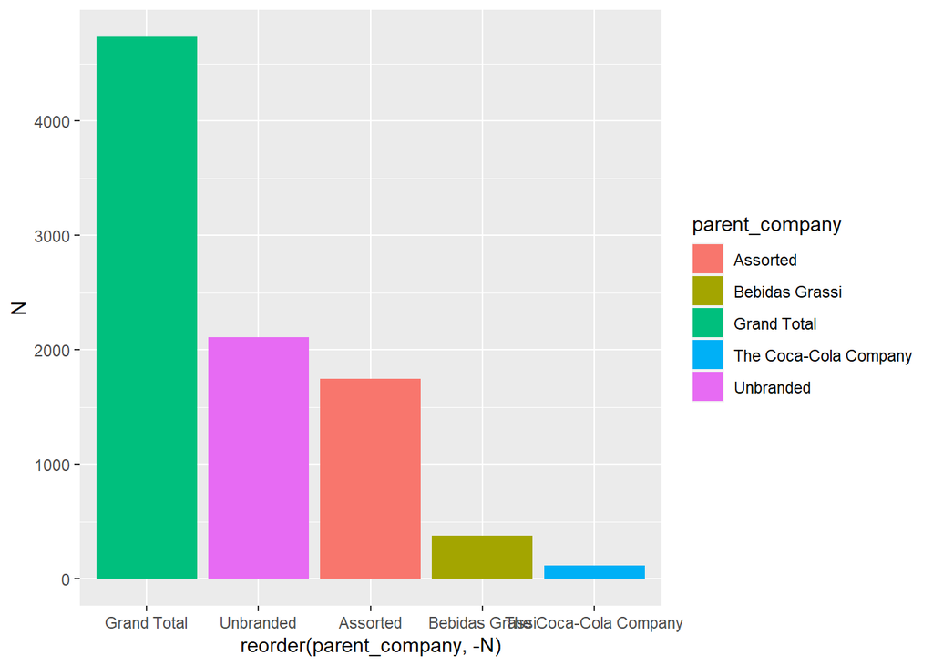

```r
plastics_bis %>%
  filter(country == "Brazil") %>%
  group_by(parent_company) %>%
  summarize(N = max(grand_total)) %>%
  top_n(5) %>%
  ggplot()+
  aes(x= reorder(parent_company , -N), N, fill = parent_company)+
  geom_col()
```

### **6. Y’a t-il une corrélation entre les évenements de comptage et la quantité de déchets en plastiques?

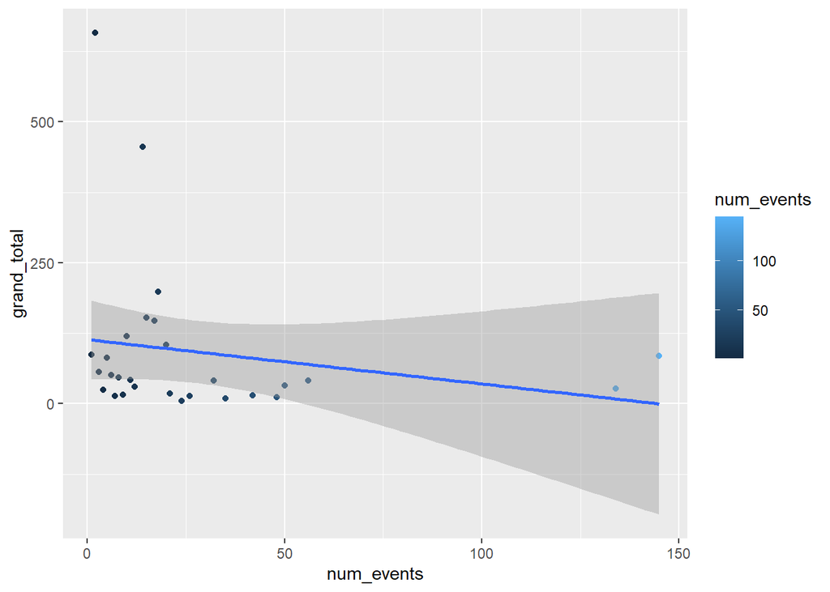

```r
plastics_bis %>%
  group_by(num_events) %>%
  summarise(grand_total = mean(grand_total, na.rm = T)) %>%
  ggplot()+
  aes(num_events, grand_total , color = num_events)+
  geom_point()+
  geom_smooth(method = "lm")
```

### **7. Quelle est la proportion de la pollution de plastique dans ces 5 pays?

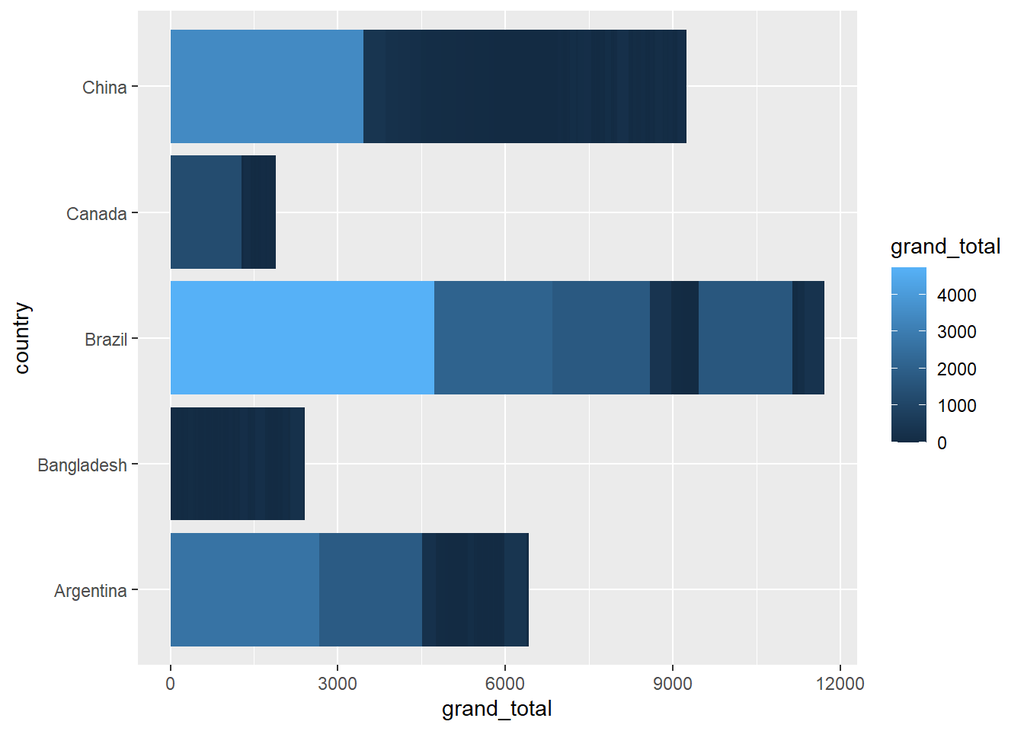

```r
plastics %>%
  filter(country %in% c( "Argentina" , "Brazil" , "Bangladesh", "China" ,"Canada")) %>%
  group_by(year) %>%
  ggplot()+
  aes(x = grand_total , y = country , fill = grand_total)+
  geom_col()
```

### **8. Quelle est la différence de participation entre les volontaires selon les pays?

```r
particip<- plastics_bis %>%
  group_by(country , year) %>%
  summarise(y_events = mean(num_events, na.rm = TRUE) ,
            y_volunteers = mean(volunteers, na.rm = TRUE)) %>%
  pivot_wider(id = "country", names_from = "year", values_from = c("y_events" , "y_volunteers")) %>%
  ungroup() %>%
  mutate(dif_volunteers = y_volunteers_2020 - y_volunteers_2019 )
```

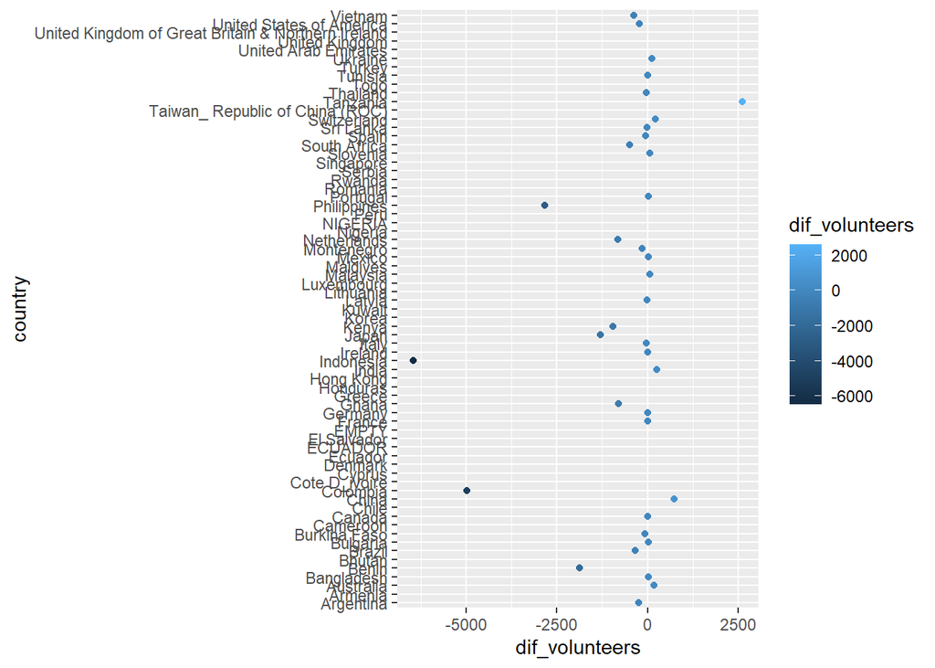

```r
particip %>%
  ggplot()+
  aes(dif_volunteers, country , color = dif_volunteers)+
  geom_point()+
  geom_smooth(method = "lm")
```

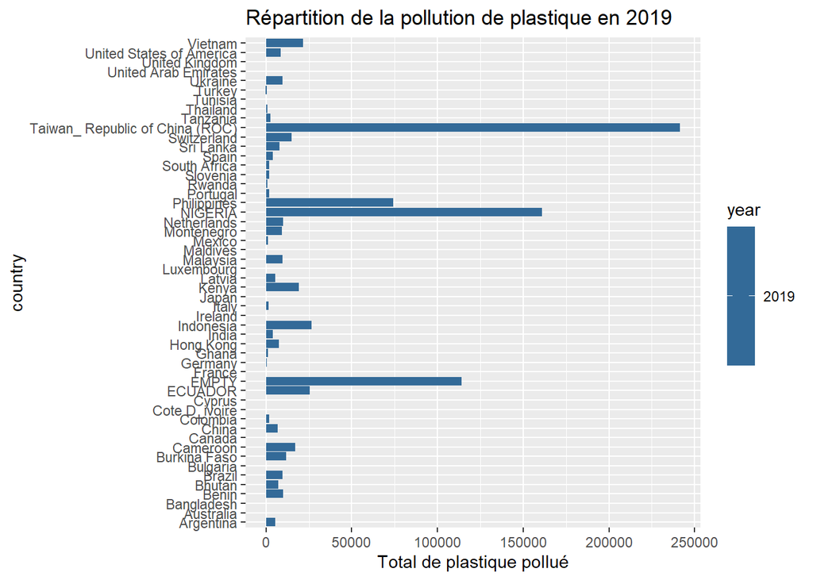

```r
plastics_bis %>%
  filter(year=="2019") %>%
  group_by(country) %>%
  ggplot()+
  aes(x= grand_total, y=country)+
  geom_bar(stat='identity',aes(fill= year))+
  labs(title = "Répartition de la pollution de plastique en 2019 ", x="Total de plastique pollué")
```

### **10. Quel est le pays qui pollue le plus en 2020?

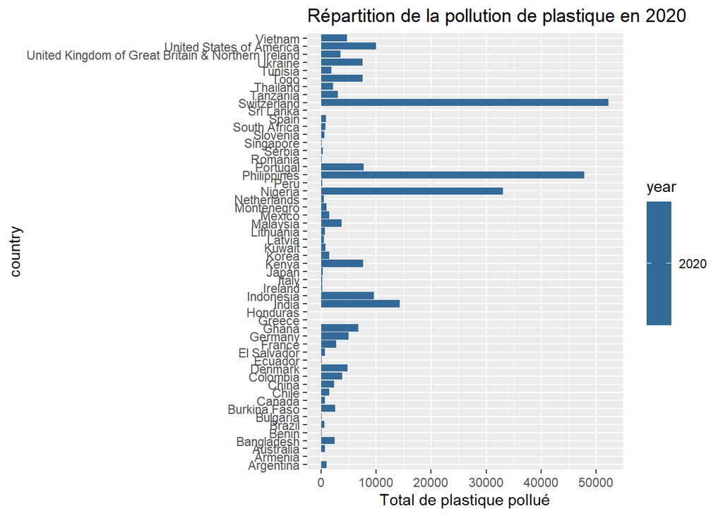

```r
plastics_bis %>%
  filter(year=="2020") %>%
  group_by(country) %>%
  ggplot()+
  aes(x= grand_total, y=country)+
  geom_bar(stat='identity',aes(fill= year))+
  labs(title = "Répartition de la pollution de plastique en 2020 ", x="Total de plastique pollué")
```

# Section par Paolo Crosetto

## Questions additionnelles

### 1. NAs

Vous avez éliminé la plupart de votre base parce qu’il y avait des données manquantes. Ceci *peut* être une bonne idéé, **ou pas**; et cela dépend de la nature de ces NAs. Vous risquez d’éliminer des observations où juste une variable que vous n’utilisez pas est manquante. Ou bien, les données sont codées de telle façon qu’un zéro est noté comme NA… et alors vous perdez de l’information.

Installez le package `naniar`, et regardez le tutoriel ici: https://cran.r-project.org/web/packages/naniar/vignettes/getting-started-w-naniar.html et essayez de visualiser les données manquantes.

Quelle est la donnée manquante la plus fréquente? Pourquoi les données sont-elles manquantes à votre avis?

A la lumière de ce que vous venez d’apprendre, cela a été une bonne idée d’éliminer les NAs?

# Installation package naniar et visdat

```r
#install.packages("naniar")
#install.packages("visdat")
library(naniar)
library(visdat)
```

# Visualisation des données manquantes

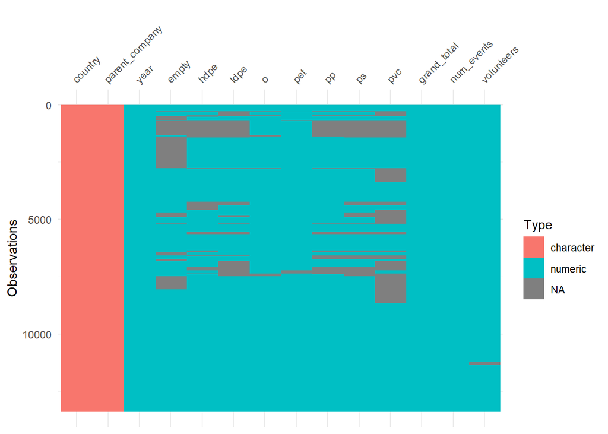

```r
library(visdat)
vis_dat(plastics)
```

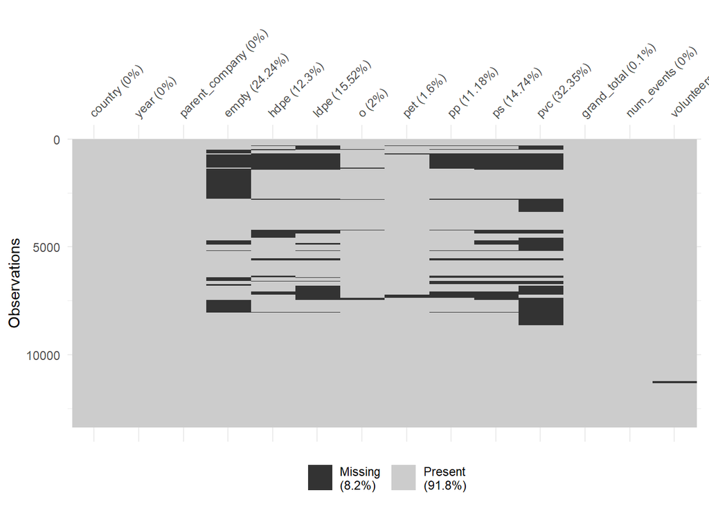

```r
vis_miss(plastics)
```

On remarque que dans notre base de données il y a 8.2% de données manquantes qui concernent principalement les variables : empty, hdpe, ldpe, o, pet, pp, ps, pvc, grand_total et volunteers. La valeur manquante la plus fréquente est pvc. Cela peut s’expliquer par le fait que dans certains pays ils ont pas pu recencé le nombre exacte de ce type de plastique.Et peut être aussi lorsque Madame Sauve a fusionné les bases de données il y a eu une perte d’information sur les types de plastiques rejetés par pays.

Ce n’est pas une bonne idée de supprimer les données manquantes, ça nous enlève des informations.

### 2. Problèmes sur Q5, Q7, Q8..

Q7: Je n’ai *pas du tout* compris ce que le plotde la question 7 est censé représenter. Pourquoi ces couleurs?

Q8: pourquoi autant de données manquantes? et s’il y en a autant, à qoui bon garder tous les pays?

# Correction Q5

en bulgarie en 2020 une compagnie : null brazil 2019 : non identified

```r
# Crrection de la base de données

plastics_bis <- plastics %>%
  .[!plastics$parent_company=="Non identified",] %>%
  .[!plastics$parent_company=="null",]

# j'ai supprimé tous les elements associés aux company dont les noms ne sont pas renseigné
```

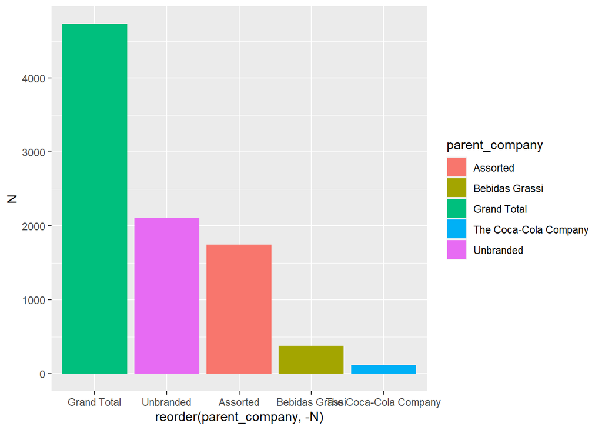

```r
plastics_bis %>%
  filter(country == "Brazil") %>%
  group_by(parent_company) %>%
  summarize(N = max(grand_total)) %>%
  top_n(5) %>%
  ggplot()+
  aes(x= reorder(parent_company , -N), N, fill = parent_company)+
  geom_col()
```

# Correction Q7 : le nombre de dechet total par pays

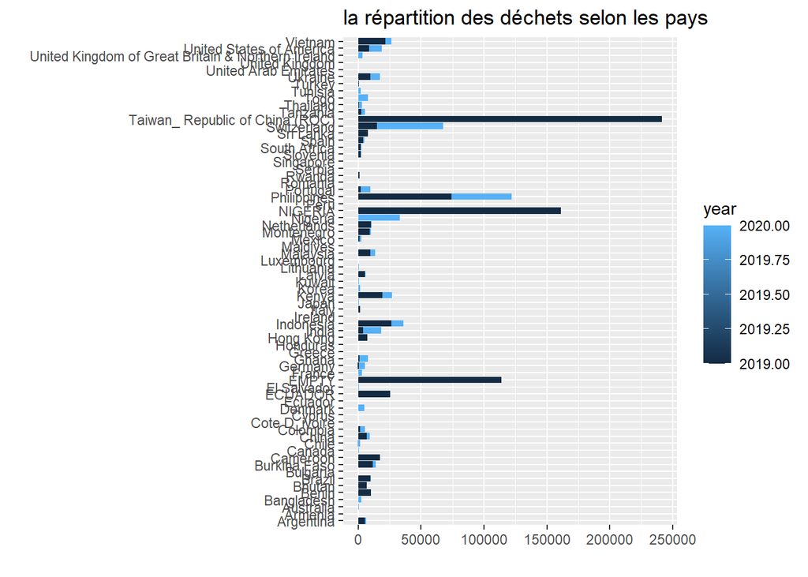

```r
plastics_bis %>%

  group_by(year) %>%
  ggplot()+
  aes(x = grand_total , y = country , fill = year)+
  geom_col()+
  labs(title = "la répartition des déchets selon les pays", x = "", y="") +
  annotate("text", x = 2019, y = 10, label =  "")
```

# Correction Q8

```r
particip<- plastics_bis %>%
  group_by(country , year) %>%
  summarise(y_events = mean(num_events, na.rm = TRUE) ,
            y_volunteers = mean(volunteers, na.rm = TRUE)) %>%
  pivot_wider(id = "country", names_from = "year", values_from = c("y_events" , "y_volunteers")) %>%
  ungroup() %>%
  mutate(dif_volunteers = y_volunteers_2020 - y_volunteers_2019 )
```

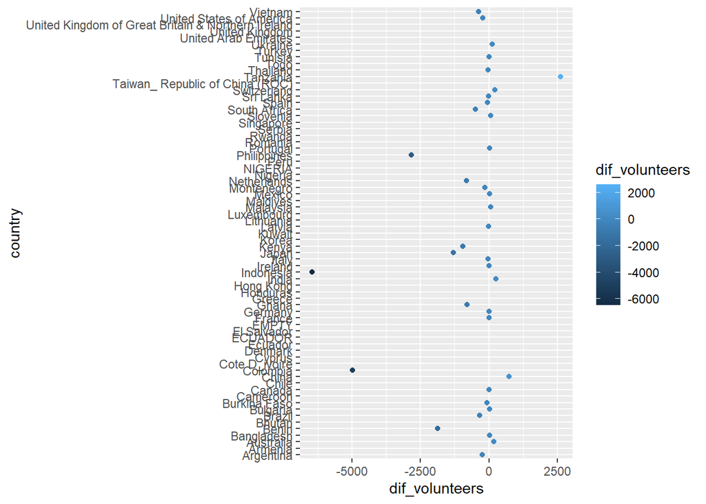

```r
particip %>%
  ggplot()+
  aes(dif_volunteers, country , color = dif_volunteers)+
  geom_point()+
  geom_smooth(method = "lm")
```

### 3. Q4: Dumbbell plot

Essayez de faire un dumbbell plot de l’évolution du nombre de volontaires par pays.

Il s’agit d’un plot dans ce style: https://static01.nyt.com/images/2021/03/24/multimedia/24-GENDER-EARNINGSGAP_RACE/24-GENDER-EARNINGSGAP_RACE-mobileMasterAt3x.png ou bien https://econlife.com/wp-content/uploads/2016/07/Dr__Paid_Less__An_Old_Title_Still_Fits_Female_Physicians_-_The_New_York_Times.png C’est à dire un “dotplot” qui montre pour chaque secteur (et sous-secteur) la différence homme/femme. Ce type de plots s’appellent aussi Dumbbell plots, examples ici: http://r-statistics.co/Top50-Ggplot2-Visualizations-MasterList-R-Code.html#3.%20Ranking

```r
#install.packages("ggalt")
library(ggalt)
```

Création d’une nouvelle table avec que les données de 2019

```r
NP19 <- plastics_bis%>%
  filter(year == 2019)%>%
  group_by(country)%>%
  summarize(total_2019 = sum(volunteers))%>%
  na.omit()
```

Création d’une nouvelle table avec que les données de 2020

```r
NP20<-plastics%>%
  filter(year == 2020)%>%
  group_by(country)%>%
  summarize(total_2020 = sum(volunteers))%>%
  na.omit()
```

On va regrouper ces deux tables :

```r
combined_NP <- right_join(NP19, NP20, by = "country") %>%
  mutate(difference = total_2020 - total_2019,
         diff_group = as.factor(ifelse(total_2020 - total_2019 > 0, "Positive", "Negative")))%>%
  top_n(abs(difference), n = 10)
```

Dumbbell Plot

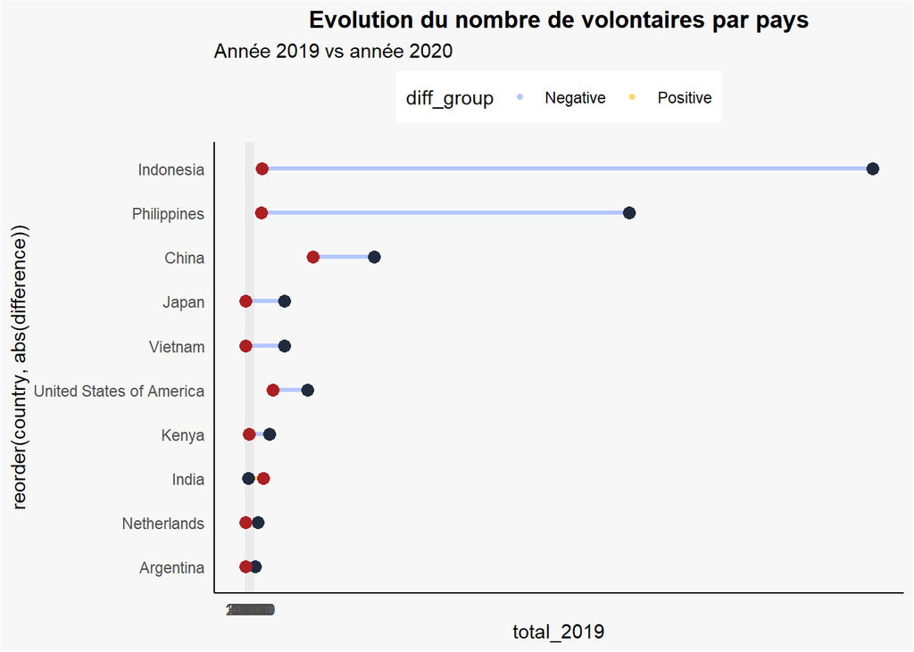

```r
library(ggplot2)
library(ggalt)
theme_set(theme_classic())


gg <- ggplot(combined_NP, aes(x=total_2019, xend=total_2020, y= reorder(country, abs(difference)), color=diff_group)) +
        geom_dumbbell(size= 1.2,
                size_x = 3,
                size_xend = 3,
                colour_x = "#202c3d",
                colour_xend = "#ac2023")+
  scale_colour_manual(values = c("#b3c6ff", "#ffd966"))+
  scale_x_continuous(breaks = c(seq(0,60000, 10000)))+

        labs(title="Evolution du nombre de volontaires par pays",
             subtitle="Année 2019 vs année 2020")+
        theme(plot.title = element_text(hjust=0.5, face="bold"),
              plot.background=element_rect(fill="#f7f7f7"),
              panel.background=element_rect(fill="#f7f7f7"),
              panel.grid.minor=element_blank(),
              panel.grid.major.y=element_blank(),
              panel.grid.major.x=element_line(),
              axis.ticks=element_blank(),
              legend.position="top",
              panel.border=element_blank())
plot(gg)
```

Pour cette question j’ai été quand même obligée de supprimer des valeurs manquantes parce que sinon j’ai le nombre total dans chaque pays mais quand je separe l’année 2019 et 2019 j’avais soit que le nombre de volontaires pour 2019 et pas pour 2020 et vice versa.